# An Exploratory Data and Network Analysis of Movies

Clarice, Daven, Lucia, Christopher and Indurain

September 6, 2019

## Introduction

In this report, we will be analysing a dataset from [Kaggle](https://www.kaggle.com/rounakbanik/the-movies-dataset#links.csv), which contains movies of different genres produced over a vast number of years. What makes this analysis interesting is that we can try and draw various conclusions based on a movie’s popularity, directors or actors involved, year of production, and so forth. Moreover, we can construct various networks in an attempt to find meaningful and interesting results. When inspecting a database of films from recent years, various interesting inferences are uncovered. A film may have a high rating yet low return on investment. Which genre would you guess is the most successful? Which actors do you think are the most popular?

We have split our Exploratory Data Analysis into four main parts:

[output not shown]

## Admin

Before we start, let’s keep this code chunk for importing the correct libraries and loading the appropriate dataset. We use pacman to load the following:

```r
pacman::p_load(rjson, jsonlite, DT,  RJSONIO, data.table, dplyr, compareDF, prettydoc, rmdformats, VIM, ggplot2, stringr, tidyr, plotly, RColorBrewer, formattable)
```

We import the dataset like this:

```r
movie_metadata <- read.csv("../data/movie_metadata.csv", sep=";")
```

In the next section we can introduce our dataset and look its content.

## Introducing The Dataset

This section of the report is quite essential for our analysis. We cannot make any interesting inferences from the dataset if we do not know what is contained within it. In this section we will try to understand exactly what we are dealing with. Thereafter, we can begin to draw interesting results. We have already read in our dataset called `movie_metadata`, so we can see the following:

The dataset contains 28 unique columns/variables, each of which are described in the table below:

| Variable Name | Description |
| --- | --- |
| color | Specifies whether a movie is in black and white or color |
| director_name | Contains name of the director of a movie |
| num_critic_for_reviews | Contains number of critic reviews per movie |
| duration | Contains duration of a movie in minutes |
| director_facebook_likes | Contains number of facebook likes for a director |
| actor_3_facebook_likes | Contains number of facebook likes for actor 3 |
| actor_2_name | Contains name of 2nd leading actor of a movie |
| actor_1_facebook_likes | Contains number of facebook likes for actor 1 |
| gross | Contains the amount a movie grossed in USD |
| genres | Contains the sub-genres to which a movie belongs |
| actor_1_name | Contains name of the actor in lead role |
| movie_title | Title of the Movie |
| num_voted_users | Contains number of users votes for a movie |
| cast_total_facebook_likes | Contains number of facebook likes for the entire cast of a movie |
| actor_3_name | Contains the name of the 3rd leading actor of a movie |
| facenumber_in_poster | Contains number of actors faces on a movie poster |
| plot_keywords | Contains key plot words associated with a movie |
| movie_imdb_link | Contains the link to the imdb movie page |
| num_user_for_reviews | Contains the number of user generated reviews per movie |
| language | Contains the language of a movie |
| country | Contains the name of the country in which a movie was made |
| content_rating | Contains maturity rating of a movie |
| budget | Contains the amount of money spent in production per movie |
| title_year | Contains the year in which a film was released |
| actor_2_facebook_likes | Contains number of facebook likes for actor 2 |
| imdb_score | Contains user generated rating per movie |
| aspect_ratio | Contains the size of the aspect ratio of a movie |
| movie_facebook_likes | Number of likes of the movie on its Facebook Page |

Furthermore, the dataset contains `5043` movies, spanning accross `96` years in 46 countries. There are `1693` unique director names and `5390` number of actors/actresses. Around `79%` of the movies are from the USA, `8%` from UK, and `13%` from other countries.

The structure of the dataset can also be used to understand our data. We can run the following code chunk to see its structure.

```r
# Get structure of dataset
str(movie_metadata)
```

```
## 'data.frame':    5043 obs. of  28 variables:
##  $ color                    : chr  "Color" "Color" "Color" "Color" ...
##  $ director_name            : chr  "James Cameron" "Gore Verbinski" "Sam Mendes" "Christopher Nolan" ...
##  $ num_critic_for_reviews   : int  723 302 602 813 NA 462 392 324 635 375 ...
##  $ duration                 : int  178 169 148 164 NA 132 156 100 141 153 ...
##  $ director_facebook_likes  : int  0 563 0 22000 131 475 0 15 0 282 ...
##  $ actor_3_facebook_likes   : int  855 1000 161 23000 NA 530 4000 284 19000 10000 ...
##  $ actor_2_name             : chr  "Joel David Moore" "Orlando Bloom" "Rory Kinnear" "Christian Bale" ...
##  $ actor_1_facebook_likes   : int  1000 40000 11000 27000 131 640 24000 799 26000 25000 ...
##  $ gross                    : int  760505847 309404152 200074175 448130642 NA 73058679 336530303 200807262 458991599 301956980 ...
##  $ genres                   : chr  "Action|Adventure|Fantasy|Sci-Fi" "Action|Adventure|Fantasy" "Action|Adventure|Thriller" "Action|Thriller" ...
##  $ actor_1_name             : chr  "CCH Pounder" "Johnny Depp" "Christoph Waltz" "Tom Hardy" ...
##  $ movie_title              : chr  "Avatar " "Pirates of the Caribbean: At World's End " "Spectre " "The Dark Knight Rises " ...
##  $ num_voted_users          : int  886204 471220 275868 1144337 8 212204 383056 294810 462669 321795 ...
##  $ cast_total_facebook_likes: int  4834 48350 11700 106759 143 1873 46055 2036 92000 58753 ...
##  $ actor_3_name             : chr  "Wes Studi" "Jack Davenport" "Stephanie Sigman" "Joseph Gordon-Levitt" ...
##  $ facenumber_in_poster     : int  0 0 1 0 0 1 0 1 4 3 ...
##  $ plot_keywords            : chr  "avatar|future|marine|native|paraplegic" "goddess|marriage ceremony|marriage proposal|pirate|singapore" "bomb|espionage|sequel|spy|terrorist" "deception|imprisonment|lawlessness|police officer|terrorist plot" ...
##  $ movie_imdb_link          : chr  "http://www.imdb.com/title/tt0499549/?ref_=fn_tt_tt_1" "http://www.imdb.com/title/tt0449088/?ref_=fn_tt_tt_1" "http://www.imdb.com/title/tt2379713/?ref_=fn_tt_tt_1" "http://www.imdb.com/title/tt1345836/?ref_=fn_tt_tt_1" ...
##  $ num_user_for_reviews     : int  3054 1238 994 2701 NA 738 1902 387 1117 973 ...
##  $ language                 : chr  "English" "English" "English" "English" ...
##  $ country                  : chr  "USA" "USA" "UK" "USA" ...
##  $ content_rating           : chr  "PG-13" "PG-13" "PG-13" "PG-13" ...
##  $ budget                   : num  2.37e+08 3.00e+08 2.45e+08 2.50e+08 NA ...
##  $ title_year               : int  2009 2007 2015 2012 NA 2012 2007 2010 2015 2009 ...
##  $ actor_2_facebook_likes   : int  936 5000 393 23000 12 632 11000 553 21000 11000 ...
##  $ imdb_score               : num  7.9 7.1 6.8 8.5 7.1 6.6 6.2 7.8 7.5 7.5 ...
##  $ aspect_ratio             : num  1.78 2.35 2.35 2.35 NA 2.35 2.35 1.85 2.35 2.35 ...
##  $ movie_facebook_likes     : int  33000 0 85000 164000 0 24000 0 29000 118000 10000 ...
```

In the next section we can start preparing the dataset for analyis by removing or simplifying some of the data.

## Pre-Processing Data

In this part of the report we attempt to look for various things that may have a negative or insignificant impact on the inferences we make on the dataset. Once we have sufficiently cleaned and prepared the dataset, we can commence with drawing various conclusions from the graphs we generate.

### Duplicate Rows

In `movie_metadata`, we have some duplicate rows, so we want to remove the 45 duplicated rows and keep the unique ones.

```r
# find duplicated rows
sum(duplicated(movie_metadata))
```

```
## [1] 45
```

```r
# Remove duplicated rows
movie_metadata <- movie_metadata[!duplicated(movie_metadata), ]
```

### Missing Values

Let’s have a look at the number of NA values in our dataset:

```r
# Find NA values
colSums(sapply(movie_metadata, is.na))
```

```
##                     color             director_name
##                         0                         0
##    num_critic_for_reviews                  duration
##                        49                        15
##   director_facebook_likes    actor_3_facebook_likes
##                       103                        23
##              actor_2_name    actor_1_facebook_likes
##                         0                         7
##                     gross                    genres
##                       874                         0
##              actor_1_name               movie_title
##                         0                         0
##           num_voted_users cast_total_facebook_likes
##                         1                         1
##              actor_3_name      facenumber_in_poster
##                         0                        13
##             plot_keywords           movie_imdb_link
##                         0                         0
##      num_user_for_reviews                  language
##                        22                         0
##                   country            content_rating
##                         0                         0
##                    budget                title_year
##                       488                       108
##    actor_2_facebook_likes                imdb_score
##                        14                         1
##              aspect_ratio      movie_facebook_likes
##                       328                         1
```

To help visualise this, have a look at the following heatmap of the missing values:

```r
# Visualise Missing Values
missing.values <- aggr(movie_metadata, sortVars = T, prop = T, sortCombs = T, cex.lab = 1.5, cex.axis = .6, cex.numbers = 5, combined = F, gap = -.2)
```

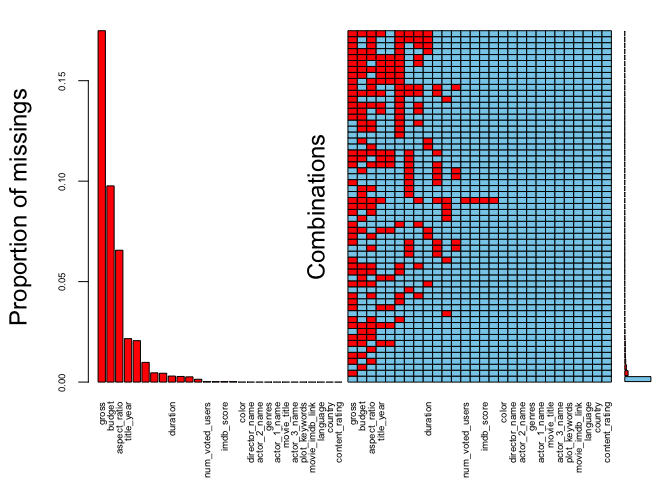

```
##
##  Variables sorted by number of missings:
##                   Variable       Count
##                      gross 0.174869948
##                     budget 0.097639056
##               aspect_ratio 0.065626251
##                 title_year 0.021608643
##    director_facebook_likes 0.020608243
##     num_critic_for_reviews 0.009803922
##     actor_3_facebook_likes 0.004601841
##       num_user_for_reviews 0.004401761
##                   duration 0.003001200
##     actor_2_facebook_likes 0.002801120
##       facenumber_in_poster 0.002601040
##     actor_1_facebook_likes 0.001400560
##            num_voted_users 0.000200080
##  cast_total_facebook_likes 0.000200080
##                 imdb_score 0.000200080
##       movie_facebook_likes 0.000200080
##                      color 0.000000000
##              director_name 0.000000000
##               actor_2_name 0.000000000
##                     genres 0.000000000
##               actor_1_name 0.000000000
##                movie_title 0.000000000
##               actor_3_name 0.000000000
##              plot_keywords 0.000000000
##            movie_imdb_link 0.000000000
##                   language 0.000000000
##                    country 0.000000000
##             content_rating 0.000000000
```

#### Gross and Budget

Since `gross` and `budget` have too many missing values (874 and 488), and we want to keep these two variables for the following analysis, we can only delete rows with null values for gross and budget because imputation will not do a good job here.

```r
# Find NA values for gross and budget
movie_metadata <- movie_metadata[!is.na(movie_metadata$gross), ]
movie_metadata <- movie_metadata[!is.na(movie_metadata$budget), ]
dim(movie_metadata)
```

```
## [1] 3857   28
```

#### Content Rating

```r
# Look at all the different types of content ratings
table(movie_metadata$content_rating)
```

```
##
##            Approved         G        GP         M     NC-17 Not Rated
##        51        17        91         1         2         6        42
##    Passed        PG     PG-13         R   Unrated         X
##         3       573      1314      1723        24        10
```

According to the history of naming these different content ratings, we find `M = GP = PG, X = NC-17`. We want to replace `M` and `GP` with `PG`, replace `X` with `NC-17`, because these two are what we use nowadays.

```r
movie_metadata$content_rating[movie_metadata$content_rating == 'M']   <- 'PG'
movie_metadata$content_rating[movie_metadata$content_rating == 'GP']  <- 'PG'
movie_metadata$content_rating[movie_metadata$content_rating == 'X']   <- 'NC-17'
```

We want to replace `Approved`, `Not Rated`, `Passed`, `Unrated` with the most common rating `R`.

```r
movie_metadata$content_rating[movie_metadata$content_rating == 'Approved']  <- 'R'
movie_metadata$content_rating[movie_metadata$content_rating == 'Not Rated'] <- 'R'
movie_metadata$content_rating[movie_metadata$content_rating == 'Passed']    <- 'R'
movie_metadata$content_rating[movie_metadata$content_rating == 'Unrated']   <- 'R'
movie_metadata$content_rating <- factor(movie_metadata$content_rating)
table(movie_metadata$content_rating)
```

```
##
##           G NC-17    PG PG-13     R
##    51    91    16   576  1314  1809
```

Blanks should be taken as missing value. Since these missing values cannot be replaced with reasonable data, we delete these rows.

```r
# Remove rows with blank content ratings
movie_metadata <- movie_metadata[!(movie_metadata$content_rating %in% ""),]
```

### Delete (Some) Rows

```r
colSums(sapply(movie_metadata, is.na))
```

```
##                     color             director_name
##                         0                         0
##    num_critic_for_reviews                  duration
##                         1                         0
##   director_facebook_likes    actor_3_facebook_likes
##                         0                         6
##              actor_2_name    actor_1_facebook_likes
##                         0                         1
##                     gross                    genres
##                         0                         0
##              actor_1_name               movie_title
##                         0                         0
##           num_voted_users cast_total_facebook_likes
##                         0                         0
##              actor_3_name      facenumber_in_poster
##                         0                         6
##             plot_keywords           movie_imdb_link
##                         0                         0
##      num_user_for_reviews                  language
##                         0                         0
##                   country            content_rating
##                         0                         0
##                    budget                title_year
##                         0                         0
##    actor_2_facebook_likes                imdb_score
##                         2                         0
##              aspect_ratio      movie_facebook_likes
##                        55                         0
```

We remove `aspect_ratio` because 1 it has a lot of missing values and 2 we will not be looking into the impact that it has on other data (we assume that it doesn’t).

```r
# Remove aspect_ratio column
movie_metadata <- subset(movie_metadata, select = -c(aspect_ratio))
```

### Add a Column

#### Gross and Budget

We have gross and budget information. So let’s add two colums: profit and percentage return on investment for further analysis.

```r
# add profit and return of investment column
movie_metadata <- movie_metadata %>%
  mutate(profit = gross - budget,
         return_on_investment_perc = (profit/budget)*100)
```

### Remove (Some) Columns

#### Colour

Next, we take a look at the influence of `colour` vs `black and white`.

```r
# Get colour display types of movies
table(movie_metadata$color)
```

```
##
##                   Black and White            Color
##                2              124             3680
```

Since `3.4%`of the data is in black and white, we can remove the `color` column it.

```r
# delete colour
movie_metadata <- subset(movie_metadata, select = -c(color))
```

#### Language

Let’s have a look at the different languages contained within the dataset.

```r
# Look at different languages
table(movie_metadata$language)
```

```
##
##            Aboriginal     Arabic    Aramaic    Bosnian  Cantonese
##          2          2          1          1          1          7
##      Czech     Danish       Dari      Dutch    English   Filipino
##          1          3          2          3       3644          1
##     French     German     Hebrew      Hindi  Hungarian Indonesian
##         34         11          2          5          1          2
##    Italian   Japanese     Kazakh     Korean   Mandarin       Maya
##          7         10          1          5         14          1
##  Mongolian       None  Norwegian    Persian Portuguese   Romanian
##          1          1          4          3          5          1
##    Russian    Spanish       Thai Vietnamese       Zulu
##          1         24          3          1          1
```

#### Country

Next, we can look at the different types of countries.

```r
table(movie_metadata$country)
```

```
##
##    Afghanistan      Argentina          Aruba      Australia        Belgium
##              1              3              1             40              1
##         Brazil         Canada          Chile          China       Colombia
##              5             63              1             13              1
## Czech Republic        Denmark        Finland         France        Georgia
##              3              9              1            103              1
##        Germany         Greece      Hong Kong        Hungary        Iceland
##             79              1             13              2              1
##          India      Indonesia           Iran        Ireland         Israel
##              5              1              4              7              2
##          Italy          Japan         Mexico    Netherlands       New Line
##             11             15             10              3              1
##    New Zealand         Norway  Official site           Peru    Philippines
##             11              4              1              1              1
##         Poland        Romania         Russia   South Africa    South Korea
##              1              2              3              3              8
##          Spain         Taiwan       Thailand             UK            USA
##             22              2              4            316           3025
##   West Germany
##              1
```

Around `79%` movies are from USA, `8%` from UK, `13%` from other countries. So we group other countries together to make this categorical variable with less levels: `USA`, `UK`, `Others`.

```r
levels(movie_metadata$country) <- c(levels(movie_metadata$country), "Others")
movie_metadata$country[(movie_metadata$country != 'USA')&(movie_metadata$country != 'UK')] <- 'Others'
movie_metadata$country <- factor(movie_metadata$country)
table(movie_metadata$country)
```

```
##
## Others     UK    USA
##    465    316   3025
```

Now that we’ve cleaned up our dataset, we can now continue to explore our data even further! In the next section we will be looking at genres, movie popularity, gross, profit, and many more other aspects pertinent to our data.

## Analysing Data

When inspecting a dataset of movies over the past few years, various interesting inferences can be uncovered. A movie may have a high rating yet low return on investment. Which genre is the most successful? Which actors are the most popular? These are some of the questions we aim to answer in this section.

We can start by performing basic analyis on our data. Thereafter, we delve a bit deeper into more specific parts of the dataset, in hopes of uncovering interesting observations.

### Basic Analysis

Let’s first have a look at the number of movies that are produced over the years.

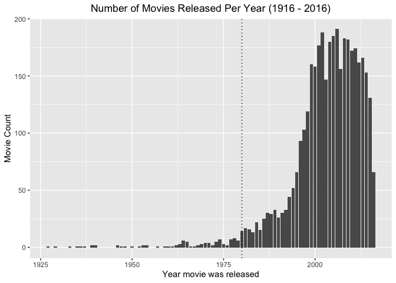

```r
ggplot(movie_metadata, aes(title_year)) +
  geom_bar() +
  labs(x = "Year movie was released", y = "Movie Count", title = "Number of Movies Released Per Year (1916 - 2016)") +
  theme(plot.title = element_text(hjust = 0.5)) +
  geom_vline(xintercept=c(1980), linetype="dotted")
```

From the graph, we see there aren’t many records of movies released before 1980. It’s better to remove those records because they might not be representative.

```r
movie_metadata <- movie_metadata[movie_metadata$title_year >= 1980,]
```

Let’s have a look at the movie counts now:

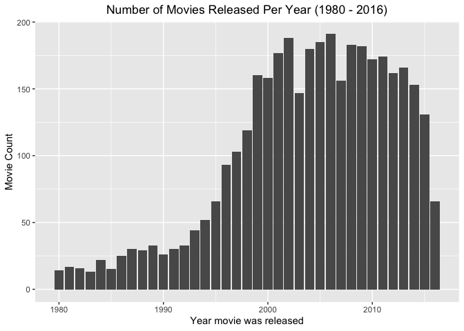

```r
ggplot(movie_metadata, aes(title_year)) +
  geom_bar() +
  labs(x = "Year movie was released", y = "Movie Count", title = "Number of Movies Released Per Year (1980 - 2016)") +
  theme(plot.title = element_text(hjust = 0.5))
```

### Movie Genre Analysis

Now we can delve into more specific things regarding movies, like `genres`.

#### Top Genres

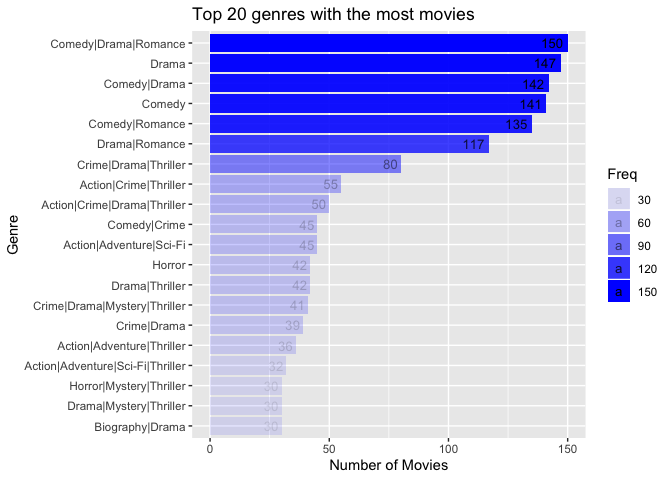

```r
genre = movie_metadata['genres']
genre = data.frame(table(genre))
genre = genre[order(genre$Freq,decreasing=TRUE),]

# Top 20 genres with the most movies
ggplot(genre[1:20,], aes(x=reorder(factor(genre), Freq), y=Freq, alpha=Freq)) +
  geom_bar(stat = "identity", fill="blue") +
  geom_text(aes(label=Freq),hjust=1.2, size=3.5)+
  xlab("Genre") +
  ylab("Number of Movies") +
  ggtitle("Top 20 genres with the most movies") +
  coord_flip()
```

#### Split Genres

As you can see, movies have multiple genres that its associated with. For analysis purposes, we choose to use the first word in the genre column, as this is likely the most accurate description.

```r
head(movie_metadata$genres)
```

```
## [1] "Action|Adventure|Fantasy|Sci-Fi" "Action|Adventure|Fantasy"
## [3] "Action|Adventure|Thriller"       "Action|Thriller"
## [5] "Action|Adventure|Sci-Fi"         "Action|Adventure|Romance"
```

Let’s split the genres separated by “|” into 8 different columns.

```r
# Split on "|"
genres_split <- str_split(movie_metadata$genres, pattern="[|]", n=2)

# Create Matrix
genres_matrix <- do.call(rbind, strsplit(movie_metadata$genres, '[|]'))

# Dataframe of genres
genres_df <- as.data.frame(genres_matrix)
```

`genre_df` consists of 8 columns, each with different genres. Let’s have a look at the frequency of all the genres.

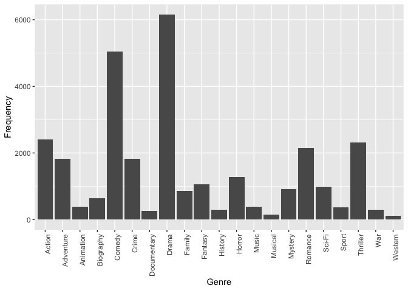

```r
# Collapse all genres into one column
genres_one_col <- gather(genres_df) %>%
  select(value)

# Plot frequency of first column
genres_one_col %>%
  group_by(value) %>%
  tally() %>%
  filter(n >= 30) %>%
  ggplot() +
  geom_bar(aes(x = value, y=n), stat="identity") +
  theme(axis.text.x = element_text(angle = 90, hjust = 1)) +
  xlab("Genre") +
  ylab("Frequency") +
  NULL
```

It is evident that the Drama and Comedy genre are the most popular to be produced. However, this does not mean that they are the most profitable, returning successful ROI’s. This will further be explored.

Previously we assumed that the first genre is the most applicable, therefore, we choose the first column as the genre for the movie and append it to the dataframe.

```r
# Take old genres column away
movie_metadata <- subset(movie_metadata, select = -c(genres))

# Take first column of genres_df and add it to MAIN df
movie_metadata$genre <- genres_df$V1
```

How does this distribution look like over the years? Lets have a look at the frequency of genres between the period of 1980 and 2016.

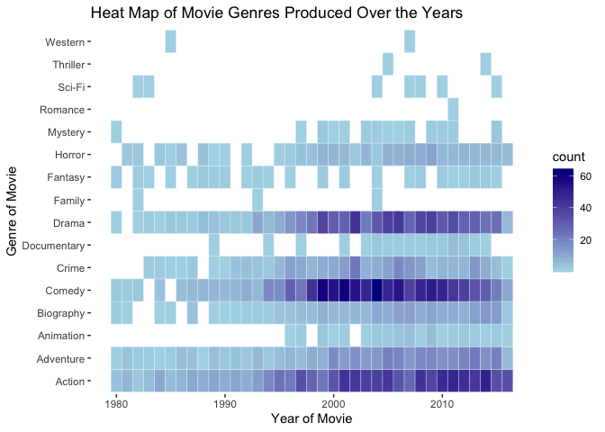

```r
movie_metadata %>%
 group_by(title_year, genre) %>%
 summarise(count = n()) %>%
 ggplot(aes(title_year, as.factor(genre))) +
 geom_tile(aes(fill=count),colour="white") +
 scale_fill_gradient(low="light blue",high = "dark blue") +
 xlab("Year of Movie") +
 ylab("Genre of Movie") +
 ggtitle("Heat Map of Movie Genres Produced Over the Years") +
  theme(panel.background = element_blank())
```

#### Which Genres are Popular?

In our dataset we have Facebook Likes and IMDB scores associated with a movie. This can help give us an indication of how popular each genre is.

```r
# Add column for total facebook likes
movie_metadata$total_facebook_likes <- movie_metadata$director_facebook_likes +
  movie_metadata$actor_3_facebook_likes + movie_metadata$actor_1_facebook_likes +
  movie_metadata$cast_total_facebook_likes + movie_metadata$actor_2_facebook_likes +
  movie_metadata$movie_facebook_likes
```

```r
# creating a data frame containing avg score, avg votes and avg fb likes
score_votes_likes <- movie_metadata %>%
  group_by(genre) %>%
  summarise(count = n(),
            avg_score = round(mean(imdb_score), 1),
            avg_votes = mean(num_voted_users),
            avg_facebook_likes = mean(total_facebook_likes),
            avg_reviews = mean(num_user_for_reviews)) %>%
  filter(count > 10)

# arranging data frame by average score
arr_score <- arrange(score_votes_likes, desc(avg_facebook_likes))

score_votes_likes
```

```
## # A tibble: 11 x 6
##    genre       count avg_score avg_votes avg_facebook_likes avg_reviews
##    <chr>       <int>     <dbl>     <dbl>              <dbl>       <dbl>
##  1 Action        937       6.3   145049.             38763.        462.
##  2 Adventure     356       6.5   133549.             40494.        355.
##  3 Animation      43       6.7    83319.             30472.        202.
##  4 Biography     200       7.1   100234.             41001.        260.
##  5 Comedy        997       6.1    64764.             23897.        198.
##  6 Crime         247       6.9   130844.             33857.        363.
##  7 Documentary    32       6.8    16159.              5623.        126.
##  8 Drama         667       6.8    85463.             31890.        320.
##  9 Fantasy        37       6.3    87311.             25452.        375.
## 10 Horror        152       5.7    66091.             21356.        407.
## 11 Mystery        24       6.6   180824.             35572.        570.
```

##### Genres VS IMDB Scores

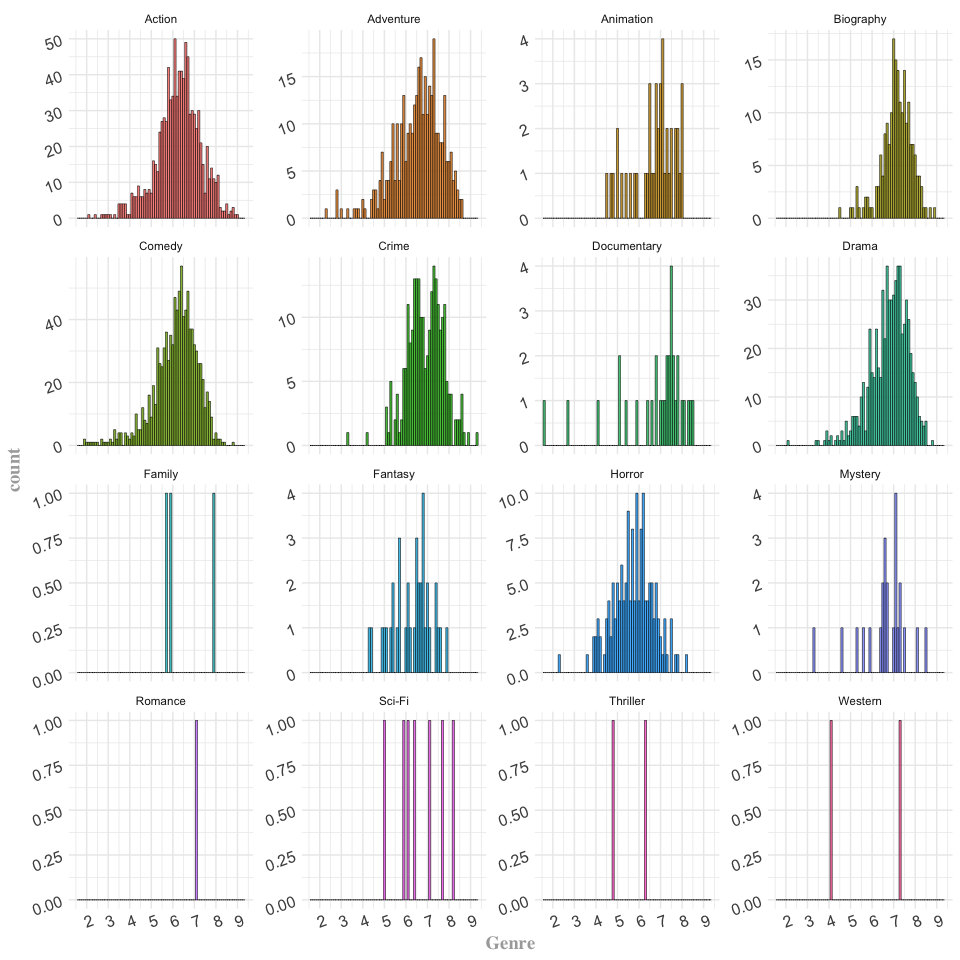

```r
# genre wise distribution of scores using a custom plot function
facet_hist_plot(movie_metadata$imdb_score,
                "Genre",
                bwidth = 0.1)+
  scale_x_continuous(breaks = seq(0, 9.3, 1))
```

```r
# plotting 10 highest rated genres
bar_plot(arr_score[1:10,],
         arr_score[1:10,]$avg_score,
         arr_score[1:10,]$avg_score,
         "| Average Score:",
         "Genres",
         "Average IMDB Score",
         "Top 10 IMDB Scores Per Genre",
         deci = 1)
```

[interactive chart not shown]

##### Genres VS Facebook Likes

Let’s now have a look at the Facebook likes.

```r
# plotting 10 highest rated genres
bar_plot(arr_score[1:10,],
         arr_score[1:10,]$avg_facebook_likes,
         arr_score[1:10,]$avg_facebook_likes,
         "| Average Score:",
         "Genres",
         "Average Facebook Likes",
         "Top 10 Facebook Likes Per Genre",
         deci = 1)
```

[interactive chart not shown]

### Popularity Analysis

IMDB ratings VS Movie Count

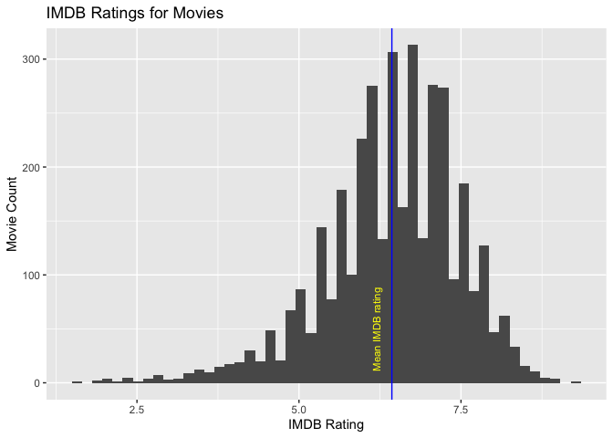

```r
ggplot(movie_metadata, aes(imdb_score)) +
 geom_histogram(bins = 50) +
 geom_vline(xintercept = mean(movie_metadata$imdb_score,na.rm = TRUE),colour = "blue") +
 ylab("Movie Count") +
 xlab("IMDB Rating") +
 ggtitle("IMDB Ratings for Movies") +
  annotate("text", label = "Mean IMDB rating",x = 6.2, y = 50, size = 3, colour = "yellow",angle=90)
```

Popularity over the years

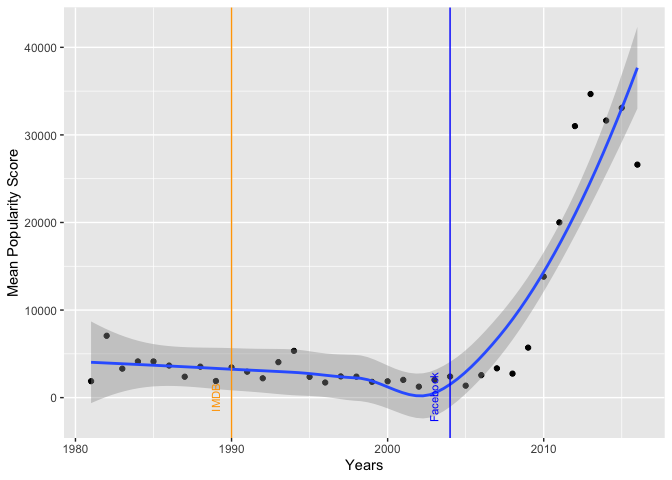

```r
#Creating the required subset of data
movies_pop <- movie_metadata %>%
 select(title_year, movie_facebook_likes) %>%
 filter(title_year > 1980) %>%
 group_by(title_year) %>%
 summarise(avg = mean(movie_facebook_likes))

#Generating the popularity Vs time plot
 ggplot(movies_pop, aes(x = title_year, y = avg)) +
   geom_point() +
   geom_smooth() +
   geom_vline(xintercept = c(1990,2004),colour = c("orange","blue")) +
   ylab("Mean Popularity Score") +
   xlab("Years") +
   annotate("text", label = "Facebook",x = 2003, y = 80, size = 3, colour = "blue",angle=90)+
   annotate("text", label = "IMDB",x = 1989, y = 80, size = 3, colour = "orange",angle=90)
```

Facebook Likes VS IMDB Score

```r
movie_metadata %>%
  plot_ly(x = ~movie_facebook_likes, y = ~imdb_score, color = ~content_rating , mode = "markers", text = ~content_rating, alpha = 0.7, type = "scatter")
```

[interactive chart not shown]

Top 20 directors with highest average IMDB score

```r
movie_metadata %>%
  group_by(director_name) %>%
  summarise(avg_imdb = mean(imdb_score)) %>%
  arrange(desc(avg_imdb)) %>%
  top_n(20, avg_imdb) %>%
  formattable(list(avg_imdb = color_bar("orange")), align = 'l')
```

| director_name | avg_imdb |
| --- | --- |
| Tony Kaye | 8.600000 |
| Damien Chazelle | 8.500000 |
| Majid Majidi | 8.500000 |
| Ron Fricke | 8.500000 |
| Christopher Nolan | 8.425000 |
| Asghar Farhadi | 8.400000 |
| Marius A. Markevicius | 8.400000 |
| Richard Marquand | 8.400000 |
| Sergio Leone | 8.400000 |
| Lee Unkrich | 8.300000 |
| Lenny Abrahamson | 8.300000 |
| Pete Docter | 8.233333 |
| Hayao Miyazaki | 8.225000 |
| Joshua Oppenheimer | 8.200000 |
| Juan José Campanella | 8.200000 |
| Quentin Tarantino | 8.200000 |
| David Sington | 8.100000 |
| Je-kyu Kang | 8.100000 |
| Terry George | 8.100000 |
| Tim Miller | 8.100000 |